# R Notebook

Denote the observed log hazard ratio with $\mu_L$ and the number of events observed in Phase 2 as $n_L$

- Likelihood $p(\mu_L | \theta ) = N(\theta, 4 / n_L)$
- Prior $\theta \sim N( \mu_P, 4 / n_P)$

Then the posterior is $N( \frac{n_L \mu_L + n_P \mu_P}{n_L + n_P}, \frac{4}{n_L + n_P})$.

If you use a noninformative prior with $\mu_L = 0$, your posterior variance is unchanged and your posterior mean is $\frac{n_L \mu_L}{n_L + n_P} = \big( \frac{n_L}{n_L + n_P} \big) \mu_L$. The bias induced by the prior is $\frac{n_L}{n_L + n_P}$. There is valid flat prior. The least informative prior sets $n_P = 1$ because it’s like “observing” only a single event. This corresponds to a $N(0, 4).$ Maybe the least informative is $n_P = 2$ because you need a two observations for a hazard ratio. This would be $N(0, 2)$.

**Note**: A $N(0, 4)$ is actually really, really noninformation for log hazard. Most of the mass is between -2 and 2 on the log scale which translates to a hazard ratio of 0.14 to 7.4. If you saw either of these hazard ratios, you would have cured cancer.

!! Distribution of hazards (not log!), looks too peaked at 0 for it to be uninformative.

```r
n_P = 30
n_L = seq(1, 300)

bias = n_L / (n_L + n_P)

plot(x = n_L, y = bias,
     type = "l",
     main = "Bias as n_P fixed at 30, n_L increases",
     xlab  = "n_L (Likelihood events)",
     ylab = "bias of likelihood mean")
```

[output not shown]

Look at “influence” (bias of the observed likelihood) when you fix likelihood sample size and increase prior sample size

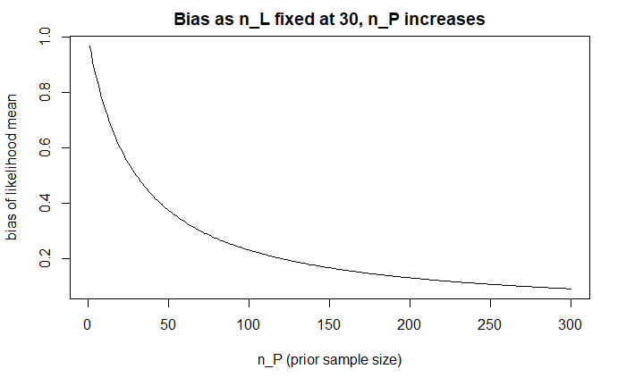

## Can we find a good balance of likelihood sample size and emperical sample size

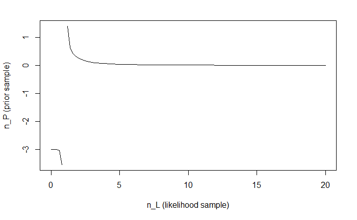